# Analysis of Berkeley DataHub Usage

## Introduction

- `user`: Anonymized hash code of a particular user
- `action`: Contains two categories: 'start' and 'stop'
- `timestamp`: Time of action (rounded to the nearest hour for anonymity

With this data, we will answer the following questions:

1. *What is the average duration of a user online?*
2. *What does the usage behavior of a particular user look like?*
3. *What does the usage look like in a:*
   1. *Semester*
   2. *Particular week*
   3. *Month*

```python
# importing libraries
import numpy as np
import pandas as pd

import matplotlib
import matplotlib.pyplot as plt
%matplotlib inline
matplotlib.style.use('ggplot')

import plotly.offline as py
py.init_notebook_mode()
import plotly.graph_objs as go

import warnings
warnings.filterwarnings('ignore')
```

### Read in the Data

```python
# read in the data
df = pd.read_json('user-starts-stops-june-12-2018.jsonl', lines=True)
df.head(10)
```

|  | action | timestamp | user |
| --- | --- | --- | --- |
| 0 | stop | 2018-01-17 06:00:00 | 0e687e7cc463d78415f7f1ef90b3282557ca971dee8675... |
| 1 | stop | 2018-01-17 06:00:00 | 0d114617160c23326050aee2ce083722b49bd7163dbfd4... |
| 2 | stop | 2018-01-17 06:00:00 | cc0bb344fd6d5c656badd63aa5a637a86b6122b759cf7a... |
| 3 | stop | 2018-01-17 06:00:00 | 631031b721c63faba68c71a88d75d8273d20a8f123673a... |
| 4 | start | 2018-01-17 06:00:00 | 736f1faedfd5b34daac22f22bac032d6b04f829bc3380b... |
| 5 | start | 2018-01-17 06:00:00 | 2261d90f35154569aac62434c045faefd2c159ea3dfcd2... |
| 6 | start | 2018-01-17 06:00:00 | 2e6888be2ce6afaa9ea4232acc327b7ad8af3741ea24ed... |
| 7 | start | 2018-01-17 06:00:00 | ec7290f65fac16cd3aa9a07f776cb85b1345fb08227eec... |
| 8 | start | 2018-01-17 06:00:00 | ae0f98922b469ec0b523f9f81f572dce4bf45be60d23ef... |
| 9 | start | 2018-01-17 06:00:00 | 9e505126a260a8c70b58ad2b857f060945a7ffb1244725... |

```python
df.describe()
```

|  | action | timestamp | user |
| --- | --- | --- | --- |
| count | 442282 | 442282 | 442282 |
| unique | 2 | 3460 | 4321 |
| top | stop | 2018-01-31 18:00:00 | 13413d734002459eef68d017d65c5a47b21b112a728b57... |
| freq | 221613 | 480 | 811 |
| first | NaN | 2018-01-17 06:00:00 | NaN |
| last | NaN | 2018-06-13 09:00:00 | NaN |

```python
# group by user, count actions/timestamps
df.groupby('user').count().sort_values(by='action', ascending=False).head()
```

| user | action | timestamp |
| --- | --- | --- |
| 13413d734002459eef68d017d65c5a47b21b112a728b5791ed1a9060e51b96887b8721cbbdb24055b143042951b0ac85cb10afc65d4b258241e5d67e8b4fa83e | 811 | 811 |
| 9cbcb70a4fc14777857e5a2941df652481f580a418a82b667e2d5fec5a8d15c40306d2d3ed295f7d2b27850f4941b4c1681081ba76e4082e1c36c9a5b3bb719a | 794 | 794 |
| 5bc384f2df8903f368978baa69a7dfed8d8f17be23c7fe46415adee216136294264e715ed16b0927619e75de601b0a504ee8701b1235b0f2ea8930e506e15c98 | 756 | 756 |
| f84707e02b0b85a50b998885f34ef10b0e3605dce3a7cc7d75bda52d112619c5cdab6454bb6b599a6b74fcd13b29f17a61cbb9cf7d1c4a5469ba8e4a73e90df9 | 754 | 754 |
| 299e3b2cafcfd89c46daa3030458dc9adb7b467130ac43768de82ebe8f131108aa27049ed9f1e61f929cc6cf0ade831768806d8eed53a643c8c84ff6e5e0a287 | 725 | 725 |

### Behavior of a Particular User

```python
# inspecting activity of most active user
highest_user = df.loc[df['user'] == '13413d734002459eef68d017d65c5a47b21b112a728b5791ed1a9060e51b96887b8721cbbdb24055b143042951b0ac85cb10afc65d4b258241e5d67e8b4fa83e']
highest_user.head()
```

|  | action | timestamp | user |
| --- | --- | --- | --- |
| 748 | start | 2018-01-17 19:00:00 | 13413d734002459eef68d017d65c5a47b21b112a728b57... |
| 987 | stop | 2018-01-17 20:00:00 | 13413d734002459eef68d017d65c5a47b21b112a728b57... |
| 2990 | start | 2018-01-18 04:00:00 | 13413d734002459eef68d017d65c5a47b21b112a728b57... |
| 3208 | stop | 2018-01-18 05:00:00 | 13413d734002459eef68d017d65c5a47b21b112a728b57... |
| 5821 | start | 2018-01-18 23:00:00 | 13413d734002459eef68d017d65c5a47b21b112a728b57... |

```python
# label encoding for action {'start': 1, 'stop': 0}
highest_user['online'] = highest_user['action'].astype('category')
highest_user['online'] = highest_user['online'].cat.rename_categories([1, 0])
highest_user.head()
```

|  | action | timestamp | user | online |
| --- | --- | --- | --- | --- |
| 748 | start | 2018-01-17 19:00:00 | 13413d734002459eef68d017d65c5a47b21b112a728b57... | 1 |
| 987 | stop | 2018-01-17 20:00:00 | 13413d734002459eef68d017d65c5a47b21b112a728b57... | 0 |
| 2990 | start | 2018-01-18 04:00:00 | 13413d734002459eef68d017d65c5a47b21b112a728b57... | 1 |
| 3208 | stop | 2018-01-18 05:00:00 | 13413d734002459eef68d017d65c5a47b21b112a728b57... | 0 |
| 5821 | start | 2018-01-18 23:00:00 | 13413d734002459eef68d017d65c5a47b21b112a728b57... | 1 |

```python
# Plot of log on-off times for highest user: Best viewed when zoomed in
data = [go.Scatter(x = highest_user['timestamp'], y = highest_user['online'], mode = 'lines', marker = dict(
                       color = '#ff6f69',
                       line = dict(width = 0.2)
                   )
                  )
       ]
py.iplot(data, filename='pandas-time-series')
```

[interactive chart not shown]

## Average Session Duration for all Users

1. Set Index to User and Timestamp
2. Reset Index to flatten dataframe

```python
# view df
df.head()
```

|  | action | timestamp | user |
| --- | --- | --- | --- |
| 0 | stop | 2018-01-17 06:00:00 | 0e687e7cc463d78415f7f1ef90b3282557ca971dee8675... |
| 1 | stop | 2018-01-17 06:00:00 | 0d114617160c23326050aee2ce083722b49bd7163dbfd4... |
| 2 | stop | 2018-01-17 06:00:00 | cc0bb344fd6d5c656badd63aa5a637a86b6122b759cf7a... |
| 3 | stop | 2018-01-17 06:00:00 | 631031b721c63faba68c71a88d75d8273d20a8f123673a... |
| 4 | start | 2018-01-17 06:00:00 | 736f1faedfd5b34daac22f22bac032d6b04f829bc3380b... |

```python
# set index to user and timestamp. Each row for a user gives the times for one particular session
df2 = df.set_index(['user','timestamp']).sort_index()
df2.head()
```

| user | timestamp | action |
| --- | --- | --- |
| 0008b495deed02bcf41a3e650127c7b0bb1d5e7a7ca564ac9c8f06da5e948c1bbbf8e7d3a6ee7471461d698bd94978c33f5321f5432a1a8447a39e5f1311fea7 | 2018-03-21 22:00:00 | start |
|  | 2018-03-22 01:00:00 | stop |
| 000d646fdd74516d6e362d322ae308bf6f734447f8e9856786c4d28ad46e4937c7658520236314d7fa9631ee0f6e5c04db8a5c74b5730eef2b5a063388e74c98 | 2018-05-22 15:00:00 | start |
|  | 2018-05-22 17:00:00 | stop |
| 0014c7a055c1ab296c51068b21bdb1e0ca552335205e652db25c28a207ae7ee91c2f227c5855df2ce4ca0f39cc9cb18d50dbdacdadac14cc86e39f519b8863ca | 2018-04-17 01:00:00 | start |

```python
# flatten dataframe
df2_flat = df2.reset_index()
df2_flat.head()
```

|  | user | timestamp | action |
| --- | --- | --- | --- |
| 0 | 0008b495deed02bcf41a3e650127c7b0bb1d5e7a7ca564... | 2018-03-21 22:00:00 | start |
| 1 | 0008b495deed02bcf41a3e650127c7b0bb1d5e7a7ca564... | 2018-03-22 01:00:00 | stop |
| 2 | 000d646fdd74516d6e362d322ae308bf6f734447f8e985... | 2018-05-22 15:00:00 | start |
| 3 | 000d646fdd74516d6e362d322ae308bf6f734447f8e985... | 2018-05-22 17:00:00 | stop |
| 4 | 0014c7a055c1ab296c51068b21bdb1e0ca552335205e65... | 2018-04-17 01:00:00 | start |

```python
# extract times column
times = df2_flat.timestamp
times[:5]
```

```
0   2018-03-21 22:00:00
1   2018-03-22 01:00:00
2   2018-05-22 15:00:00
3   2018-05-22 17:00:00
4   2018-04-17 01:00:00
Name: timestamp, dtype: datetime64[ns]
```

```python
# for loop to calculate consecutive differences (session durations)
diffs = []
for i in np.arange(0, len(times) - 2, 2):
    diffs.append(times[i+1] - times[i])
diffs[:10]
```

```
[Timedelta('0 days 03:00:00'),
 Timedelta('0 days 02:00:00'),
 Timedelta('0 days 03:00:00'),
 Timedelta('0 days 02:00:00'),
 Timedelta('0 days 01:00:00'),
 Timedelta('0 days 01:00:00'),
 Timedelta('0 days 04:00:00'),
 Timedelta('0 days 05:00:00'),
 Timedelta('0 days 03:00:00'),
 Timedelta('0 days 08:00:00')]
```

```python
# create df of session durations
times_df = pd.DataFrame({'col':diffs})
times_df['col'] = times_df[times_df['col'] >= pd.Timedelta(0)].col
times_df.head()
```

|  | col |
| --- | --- |
| 0 | 03:00:00 |
| 1 | 02:00:00 |
| 2 | 03:00:00 |
| 3 | 02:00:00 |
| 4 | 01:00:00 |

```python
# view value counts for durations
times_df['col'].value_counts()[:5]
```

```
01:00:00    53355
02:00:00    38089
03:00:00    21309
00:00:00    15607
04:00:00    13078
Name: col, dtype: int64
```

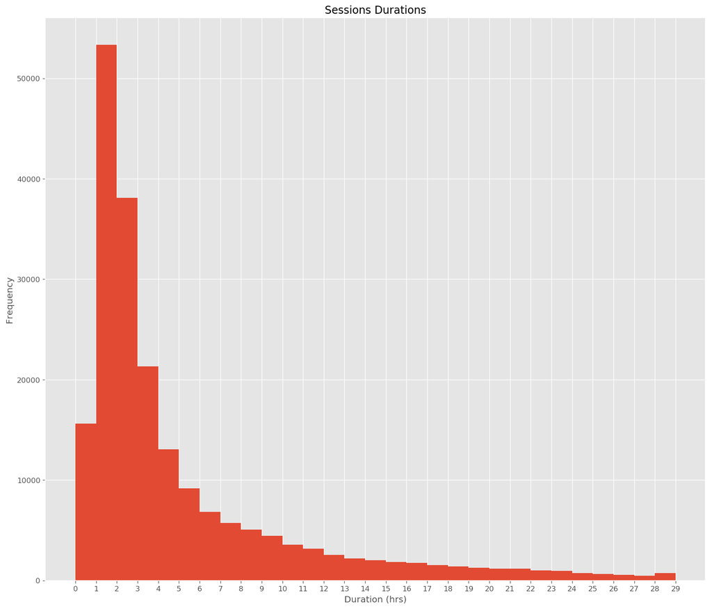

```python
# plot durations
fig=plt.figure(figsize=(16, 14), dpi= 120, facecolor='w', edgecolor='k')
(times_df["col"] / pd.Timedelta(hours = 1)).hist(bins = range(0, 30, 1))
plt.title('Sessions Durations')
plt.xlabel('Duration (hrs)')
plt.xticks(np.arange(0, 30, 1))
plt.ylabel('Frequency');
```

```python
print('Average session durations:  ' + str(times_df['col'].mean()))
```

```
Average session durations:  0 days 15:18:29.906853
```

We see a distribution that is exponentially decreasing as the durations increases. So most users spend 1 - 4 hours online. However, there are logs which indicate durations of multiple hours and in some cases greater than one day. One possible explanation for this is idle time on a user's device

## Usage in Different Time Frames

### Start Actions in a Semester

```python
df2_flat.head()
```

|  | user | timestamp | action |
| --- | --- | --- | --- |
| 0 | 0008b495deed02bcf41a3e650127c7b0bb1d5e7a7ca564... | 2018-03-21 22:00:00 | start |
| 1 | 0008b495deed02bcf41a3e650127c7b0bb1d5e7a7ca564... | 2018-03-22 01:00:00 | stop |
| 2 | 000d646fdd74516d6e362d322ae308bf6f734447f8e985... | 2018-05-22 15:00:00 | start |
| 3 | 000d646fdd74516d6e362d322ae308bf6f734447f8e985... | 2018-05-22 17:00:00 | stop |
| 4 | 0014c7a055c1ab296c51068b21bdb1e0ca552335205e65... | 2018-04-17 01:00:00 | start |

```python
# number of start actions for each user
num_actions = (df2_flat.groupby('user')[['timestamp']].count() / 2)
num_actions.head()
```

| user | timestamp |
| --- | --- |
| 0008b495deed02bcf41a3e650127c7b0bb1d5e7a7ca564ac9c8f06da5e948c1bbbf8e7d3a6ee7471461d698bd94978c33f5321f5432a1a8447a39e5f1311fea7 | 1.0 |
| 000d646fdd74516d6e362d322ae308bf6f734447f8e9856786c4d28ad46e4937c7658520236314d7fa9631ee0f6e5c04db8a5c74b5730eef2b5a063388e74c98 | 1.0 |
| 0014c7a055c1ab296c51068b21bdb1e0ca552335205e652db25c28a207ae7ee91c2f227c5855df2ce4ca0f39cc9cb18d50dbdacdadac14cc86e39f519b8863ca | 1.0 |
| 00396c3e062627a97dff6a6d994a0e75c1d2d0c009a8ab271c9180dd8136a1dfbd15351daf0d351dcafef089c4238911d1486c825a2e7cbf878652733604ce4f | 132.0 |
| 006c1fc29fa3207309794e91929c23b590b6f3d144db0c07a9fd9e9ca01740165b61bbd9b602fe2305bc9f25119150570809fe31d7c7da2b22f92691405af939 | 1.0 |

```python
num_actions.mean()
```

```
timestamp    51.178199
dtype: float64
```

51.17 is the number of average 'start' actions in one semester

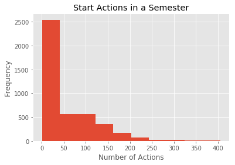

```python
# distribution of start actions in a semester
num_actions['timestamp'].hist()
plt.title('Start Actions in a Semester')
plt.xlabel('Number of Actions')
plt.ylabel('Frequency');
```

```python
# df of start actions per hour
sem_counts = df2_flat.loc[df2_flat['action'] == 'start'].groupby('timestamp').count()
sem_counts.head()
```

| timestamp | user | action |
| --- | --- | --- |
| 2018-01-17 06:00:00 | 35 | 35 |
| 2018-01-17 07:00:00 | 38 | 38 |
| 2018-01-17 08:00:00 | 17 | 17 |
| 2018-01-17 09:00:00 | 17 | 17 |
| 2018-01-17 10:00:00 | 11 | 11 |

```python
# plot for usage in semester
data = [go.Scatter(x = sem_counts.index,
                   y = sem_counts['action'],
                   mode = 'lines+markers', marker = dict(
                       color = '#ff6f69',
                       line = dict(width = 0.2))
                  )
       ]
layout = dict(title = 'Start Actions in a Semester',
              yaxis = dict(zeroline = False, title = 'Number of Start Actions'),
              xaxis = dict(zeroline = False, title = 'Date')
             )
fig = dict(data=data, layout=layout)
py.iplot(fig, filename='pandas-time-series')
```

[interactive chart not shown]

The plot above shows usage across the semester. One can zoom in to view usage in a partiuclar time frame. In the following sections we will analyze the usage in a given week and month

### Start Actions in a Week (1/31 - 2/6)

```python
df2_flat.head()
```

|  | user | timestamp | action |
| --- | --- | --- | --- |
| 0 | 0008b495deed02bcf41a3e650127c7b0bb1d5e7a7ca564... | 2018-03-21 22:00:00 | start |
| 1 | 0008b495deed02bcf41a3e650127c7b0bb1d5e7a7ca564... | 2018-03-22 01:00:00 | stop |
| 2 | 000d646fdd74516d6e362d322ae308bf6f734447f8e985... | 2018-05-22 15:00:00 | start |
| 3 | 000d646fdd74516d6e362d322ae308bf6f734447f8e985... | 2018-05-22 17:00:00 | stop |
| 4 | 0014c7a055c1ab296c51068b21bdb1e0ca552335205e65... | 2018-04-17 01:00:00 | start |

```python
# subset dataframe to week of 1/31-2/6
week = df2_flat[(df2_flat.timestamp > '2018-01-31') & (df2_flat.timestamp < '2018-02-07')]
week.head()
```

|  | user | timestamp | action |
| --- | --- | --- | --- |
| 40 | 00396c3e062627a97dff6a6d994a0e75c1d2d0c009a8ab... | 2018-01-31 18:00:00 | start |
| 41 | 00396c3e062627a97dff6a6d994a0e75c1d2d0c009a8ab... | 2018-01-31 19:00:00 | stop |
| 42 | 00396c3e062627a97dff6a6d994a0e75c1d2d0c009a8ab... | 2018-02-01 19:00:00 | start |
| 43 | 00396c3e062627a97dff6a6d994a0e75c1d2d0c009a8ab... | 2018-02-01 21:00:00 | stop |
| 44 | 00396c3e062627a97dff6a6d994a0e75c1d2d0c009a8ab... | 2018-02-05 02:00:00 | start |

```python
# number of start actions for each user
num_in_week = (week.groupby('user')[['timestamp']].count() / 2)
num_in_week.head()
```

| user | timestamp |
| --- | --- |
| 00396c3e062627a97dff6a6d994a0e75c1d2d0c009a8ab271c9180dd8136a1dfbd15351daf0d351dcafef089c4238911d1486c825a2e7cbf878652733604ce4f | 7.0 |
| 008bc3e61e24d87d26423051471e2974494e43abab20fe78cc53fc22f34cf9b1aa2fbd477e1acf52da6336a004aea97f317a6d34cd177df007242cf54ee93c6c | 6.0 |
| 00f1e15b675b2cfc0d0a36f0e72a6436a61a7cfd522e6764e2547c154dfe0e328fb79ee92296f4e7625ce80824c5e505904b954d578abb4890b40bd155e6ad55 | 10.0 |
| 017386337a4022d190f55bb4d41f772dbed78263d96caef6602038291cdf5302a7e73a3824a414172d2b8e33f3374571fdf8ee87e173f49e0d590aa06cc32b9a | 2.0 |
| 017f7612a7791ea10dcf2b71b24b29ef54003ce2c0121233706277cfe94fe2ce96d1c82ef26e299f22070aad2d428e53a4d0816edf9e99aff88a911ec99fe4ca | 12.5 |

```python
num_in_week.mean()
```

```
timestamp    7.395843
dtype: float64
```

7.39 is the number of average 'start' actions in one week per user

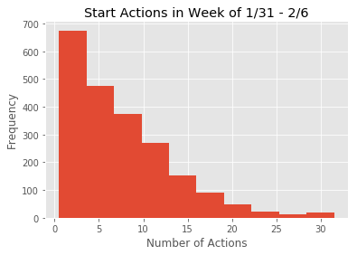

```python
# distribution of start actions in a week
num_in_week['timestamp'].hist()
plt.title('Start Actions in Week of 1/31 - 2/6')
plt.xlabel('Number of Actions')
plt.ylabel('Frequency');
```

```python
# df of start actions per hour
week_counts = week.loc[week['action'] == 'start'].groupby('timestamp').count()
week_counts.head()
```

| timestamp | user | action |
| --- | --- | --- |
| 2018-01-31 01:00:00 | 167 | 167 |
| 2018-01-31 02:00:00 | 125 | 125 |
| 2018-01-31 03:00:00 | 158 | 158 |
| 2018-01-31 04:00:00 | 158 | 158 |
| 2018-01-31 05:00:00 | 168 | 168 |

```python
# plot for usage in week
data = [go.Scatter(x = week_counts.index, y = week_counts['action'], mode = 'lines+markers',
                   marker = dict(
                       color = '#ff6f69',
                       line = dict(width = 0.2)
                   )
                  )
       ]
layout = dict(title = 'Start Actions in Week of 1/31 - 2/6',
              yaxis = dict(zeroline = False, title = 'Number of Start Actions'),
              xaxis = dict(zeroline = False, title = 'Date')
             )
fig = dict(data=data, layout=layout)
py.iplot(fig, filename='pandas-time-series')
```

[interactive chart not shown]

### Start Actions in a Month (February)

```python
df2_flat.head()
```

|  | user | timestamp | action |
| --- | --- | --- | --- |
| 0 | 0008b495deed02bcf41a3e650127c7b0bb1d5e7a7ca564... | 2018-03-21 22:00:00 | start |
| 1 | 0008b495deed02bcf41a3e650127c7b0bb1d5e7a7ca564... | 2018-03-22 01:00:00 | stop |
| 2 | 000d646fdd74516d6e362d322ae308bf6f734447f8e985... | 2018-05-22 15:00:00 | start |
| 3 | 000d646fdd74516d6e362d322ae308bf6f734447f8e985... | 2018-05-22 17:00:00 | stop |
| 4 | 0014c7a055c1ab296c51068b21bdb1e0ca552335205e65... | 2018-04-17 01:00:00 | start |

```python
# subset dataframe to month of February
month = df2_flat[(df2_flat.timestamp > '2018-01-31') & (df2_flat.timestamp < '2018-03-01')]
month.head()
```

|  | user | timestamp | action |
| --- | --- | --- | --- |
| 40 | 00396c3e062627a97dff6a6d994a0e75c1d2d0c009a8ab... | 2018-01-31 18:00:00 | start |
| 41 | 00396c3e062627a97dff6a6d994a0e75c1d2d0c009a8ab... | 2018-01-31 19:00:00 | stop |
| 42 | 00396c3e062627a97dff6a6d994a0e75c1d2d0c009a8ab... | 2018-02-01 19:00:00 | start |
| 43 | 00396c3e062627a97dff6a6d994a0e75c1d2d0c009a8ab... | 2018-02-01 21:00:00 | stop |
| 44 | 00396c3e062627a97dff6a6d994a0e75c1d2d0c009a8ab... | 2018-02-05 02:00:00 | start |

```python
# number of start actions for each user
num_in_month = (month.groupby('user')[['timestamp']].count() / 2)
num_in_month.head()
```

| user | timestamp |
| --- | --- |
| 00396c3e062627a97dff6a6d994a0e75c1d2d0c009a8ab271c9180dd8136a1dfbd15351daf0d351dcafef089c4238911d1486c825a2e7cbf878652733604ce4f | 41.5 |
| 008bc3e61e24d87d26423051471e2974494e43abab20fe78cc53fc22f34cf9b1aa2fbd477e1acf52da6336a004aea97f317a6d34cd177df007242cf54ee93c6c | 18.5 |
| 008ff6058df6d09babf1abe81363a9d8fdfac751f0bb75fc4e973a17ef3176c1f73b01a50803c71f8e2bd3cb442cb2c0ad55f15b82514cc48fc92ab7b19d426b | 1.0 |
| 00e689ae6ec6f3208a59d957a0797f1a60a56710b8a4a400580ac33a812c24e9e9a194fa05c06407b889aa607e6f99a6b731b89faabbab61acf40aaceb6a49d1 | 3.0 |
| 00f1e15b675b2cfc0d0a36f0e72a6436a61a7cfd522e6764e2547c154dfe0e328fb79ee92296f4e7625ce80824c5e505904b954d578abb4890b40bd155e6ad55 | 92.5 |

```python
num_in_month.mean()
```

```
timestamp    24.119296
dtype: float64
```

24.119 is the number of average 'start' actions in one month per user

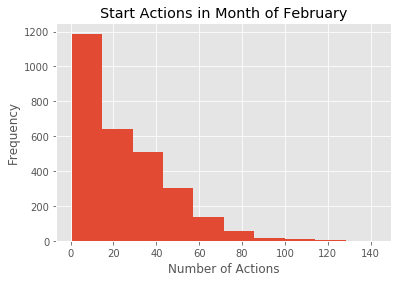

```python
# distribution of start actions in a month
num_in_month['timestamp'].hist()
plt.title('Start Actions in Month of February')
plt.xlabel('Number of Actions')
plt.ylabel('Frequency');
```

```python
# df of start actions per hour
month_counts = month.loc[month['action'] == 'start'].groupby('timestamp').count()
month_counts.head()
```

| timestamp | user | action |
| --- | --- | --- |
| 2018-01-31 01:00:00 | 167 | 167 |
| 2018-01-31 02:00:00 | 125 | 125 |
| 2018-01-31 03:00:00 | 158 | 158 |
| 2018-01-31 04:00:00 | 158 | 158 |
| 2018-01-31 05:00:00 | 168 | 168 |

```python
# plot for usage in month
data = [go.Scatter(x = month_counts.index, y = month_counts['action'], mode = 'lines+markers',
                   marker = dict(
                       color = '#ff6f69',
                       line = dict(width = 0.2)
                   )
                  )
       ]
layout = dict(title = 'Start Actions in February',
              yaxis = dict(zeroline = False, title = 'Number of Start Actions'),
              xaxis = dict(zeroline = False, title = 'Date')
             )
fig = dict(data=data, layout=layout)
py.iplot(fig, filename='pandas-time-series')
```

[interactive chart not shown]

One can see that there are usually two to three spikes in usage per week in February.

### Start Actions in April

```python
# subset dataframe to month of April
month_2 = df2_flat[(df2_flat.timestamp > '2018-04') & (df2_flat.timestamp < '2018-05')]
# df of start actions per hour
month_2_counts = month_2.loc[month_2['action'] == 'start'].groupby('timestamp').count()
# plot for usage in April
data = [go.Scatter(x = month_2_counts.index, y = month_2_counts['action'], mode = 'lines+markers',
                   marker = dict(
                       color = '#ff6f69',
                       line = dict(width = 0.2)
                   )
                  )
       ]
layout = dict(title = 'Start Actions in April',
              yaxis = dict(zeroline = False, title = 'Number of Start Actions'),
              xaxis = dict(zeroline = False, title = 'Date')
             )
fig = dict(data=data, layout=layout)
py.iplot(fig, filename='pandas-time-series')
```

[interactive chart not shown]

User behavior looks similar but the number of actions in April is on average less than those in February

## Concluding Remarks

In this notebook we visualized user behavior in different contexts. This is useful for the Datahub and Jupyter infrastructure team to keep track of usage and peak times on the server.

There are more possible use cases for this data, if we had more information such as whether the student is working on DATA 8, or connectors or modules. For example, with DATA 8 information, we could deeply analyze student's online behavior during the semester.